# Final Project - Popular Spotify Songs

Johnny Arguedas & Mark Hageman

11/27/2020

**Mid-term review for this project provided by Eunsun Yook**

### Section 1: Introduction

Streaming music services have been able to collect a wealth of data for song characteristics, amount of streams, and user interaction. Spotify has taken this data to create playlists curated to a user’s taste based on their listening habits. Considering how songs have been quantified by Spotify, is it possible to find correlations for a song’s popularity based on the other quantifiable fields Spotify makes available?

With the [Spotify](https://www.spotify.com/us/) dataset retrieved with the `spotifyr` package, we will look at 12 variables from almost 33,000 songs and see how they interact with each other, and whether they are significant in determining popularity. As genres of music can have very different characteristics, it may make more sense to gauge popularity based on each genre’s representative statistics rather than overall.

We will first compare variables to determine which have influence on the popularity of a song. We will then apply a multiple linear regression to the data to make a prediction as to what characteristics are likely to produce a popular song.

A predictive model of popularity can help songwriters craft a song based on data-driven methods. Users will also benefit by being able to discover songs based on their preferred characteristics, and see whether they prefer more or less popular songs.

### Section 2: Required Packages

```r
library(tidyverse)
library(scales)
library(table1)
library(htmltools)
library(cowplot)
library(rlang)
library(Hmisc)
library(gridExtra)
library(ggcorrplot)
```

This analysis will make use of the following packages:

- [tidyverse](https://www.tidyverse.org/) - A collection of various packages designed to make it easier to make data tidy for analysis
- [scales](https://www.rdocumentation.org/packages/scales/versions/0.4.1) - A package with various string formatting functions
- [table1](https://cran.r-project.org/web/packages/table1/vignettes/table1-examples.html) - A package for the creation of HTML tables of descriptive statistics
- [htmltools](https://cran.r-project.org/web/packages/htmltools/index.html) - A package to enable the inclusion of external HTML files
- [cowplot](https://cran.r-project.org/web/packages/cowplot/vignettes/introduction.html) - A package that enhances ggplot by adding themes
- [rlang](https://cran.r-project.org/web/packages/rlang/index.html) - A package that provides tools to work with core features of R and `tidyverse`
- [Hmisc](https://cran.r-project.org/web/packages/Hmisc/index.html) - A package that contains many functions useful for data analysis, high-level graphics, utility operations, and more
- [gridExtra](https://cran.r-project.org/web/packages/gridExtra/index.html) - A package to help work with “grid” graphics
- [ggcorrplot](https://cran.r-project.org/web/packages/ggcorrplot/) - A package to produce a visualized correlation matrix using `ggplot2`

### Section 3: Data Preparation

The data used in this analysis is available as part of the [tidytuesdayR](https://github.com/rfordatascience/tidytuesday/blob/master/data/2020/2020-01-21/readme.md) package, and is also available for download [here](https://raw.githubusercontent.com/rfordatascience/tidytuesday/master/data/2020/2020-01-21/spotify_songs.csv).

The codebook is also available on the [tidytuesday](https://github.com/rfordatascience/tidytuesday/blob/master/data/2020/2020-01-21/readme.md) GitHub page.

```r
songs <- read.csv('spotify_songs.csv', stringsAsFactors = FALSE)
```

The data set, which was originally created on 2020-01-21, consists of 32,833 records, each with 23 columns. Each record represents a single song, and the columns represent various aspects of each song. The codebook includes the variable definitions.

Because the columns are named sensibly, we won’t need to re-name any of them.

In examining the structure of the data set, we can see that `track_album_release_date` should be re-formatted as a date, and that `playlist_genre` and `playlist_subgenre` should be made into factors.

```r
str(songs)
songs$track_album_release_date <- as.Date(songs$track_album_release_date)
songs$playlist_genre <- as.factor(songs$playlist_genre)
songs$playlist_subgenre <- as.factor(songs$playlist_subgenre)
```

Is there any missing data?

```r
nrow(songs[complete.cases(songs), ])
```

```
## [1] 30942
```

```r
colSums(is.na(songs))
```

```
##                 track_id               track_name             track_artist
##                        0                        5                        5
##         track_popularity           track_album_id         track_album_name
##                        0                        0                        5
## track_album_release_date            playlist_name              playlist_id
##                     1886                        0                        0
##           playlist_genre        playlist_subgenre             danceability
##                        0                        0                        0
##                   energy                      key                 loudness
##                        0                        0                        0
##                     mode              speechiness             acousticness
##                        0                        0                        0
##         instrumentalness                 liveness                  valence
##                        0                        0                        0
##                    tempo              duration_ms
##                        0                        0
```

The NA values in this data set exist in the `track_name`, `track_artist`, `track_album_name`, and `track_album_release_date`. Given the nature of the columns with missing values, it does not make sense for us to make any imputations.

How many rows still have missing data?

```r
na_rows <- nrow(songs) - nrow(songs[complete.cases(songs), ])
pct_na_rows <- na_rows / nrow(songs)
```

Only **1891** rows are still missing data at this point. This is only about **6%** of the total number of rows, so we’ll just drop those rows from the data set.

```r
songs <- na.omit(songs)
```

Next we’ll look at summaries of each of the numeric values to be sure they make sense, and check for any outliers.

```r
songs %>%
  summarise_if(is.numeric, mean)
```

```
##   track_popularity danceability    energy      key  loudness      mode
## 1         42.75609    0.6572603 0.6988573 5.368011 -6.639354 0.5609528
##   speechiness acousticness instrumentalness  liveness   valence    tempo
## 1   0.1082296    0.1759632       0.08695591 0.1899777 0.5050244 120.9423
##   duration_ms
## 1    223946.6
```

There do not appear to be any outliers among the numeric variables, and all values are within the stated ranges (i.e., values such as `danceability` and `energy` are measured on a scale of 0.0 - 1.0). `mode` is binary variable with 0 and 1 as the only possible values. The longest song has a duration of 517810, which is about 8.63 minutes, which seems entirely reasonable.

Finally, there are several columns we won’t need for our analysis, so we’ll drop them.

```r
unused_cols <- c('track_id', 'track_album_id', 'track_album_name',
                 'playlist_name', 'playlist_id', 'playlist_subgenre')
songs <- songs[ , -which(names(songs) %in% c(unused_cols))]
```

The data is now clean, with **30942** observations of **17** variables. Here’s what it looks like:

```r
head(songs)
```

```
##                                              track_name     track_artist
## 1 I Don't Care (with Justin Bieber) - Loud Luxury Remix       Ed Sheeran
## 2                       Memories - Dillon Francis Remix         Maroon 5
## 3                       All the Time - Don Diablo Remix     Zara Larsson
## 4                     Call You Mine - Keanu Silva Remix The Chainsmokers
## 5               Someone You Loved - Future Humans Remix    Lewis Capaldi
## 6     Beautiful People (feat. Khalid) - Jack Wins Remix       Ed Sheeran
##   track_popularity track_album_release_date playlist_genre danceability energy
## 1               66               2019-06-14            pop        0.748  0.916
## 2               67               2019-12-13            pop        0.726  0.815
## 3               70               2019-07-05            pop        0.675  0.931
## 4               60               2019-07-19            pop        0.718  0.930
## 5               69               2019-03-05            pop        0.650  0.833
## 6               67               2019-07-11            pop        0.675  0.919
##   key loudness mode speechiness acousticness instrumentalness liveness valence
## 1   6   -2.634    1      0.0583       0.1020         0.00e+00   0.0653   0.518
## 2  11   -4.969    1      0.0373       0.0724         4.21e-03   0.3570   0.693
## 3   1   -3.432    0      0.0742       0.0794         2.33e-05   0.1100   0.613
## 4   7   -3.778    1      0.1020       0.0287         9.43e-06   0.2040   0.277
## 5   1   -4.672    1      0.0359       0.0803         0.00e+00   0.0833   0.725
## 6   8   -5.385    1      0.1270       0.0799         0.00e+00   0.1430   0.585
##     tempo duration_ms
## 1 122.036      194754
## 2  99.972      162600
## 3 124.008      176616
## 4 121.956      169093
## 5 123.976      189052
## 6 124.982      163049
```

The variables we are concerned with are `track_album_release_date`, `track_artist`, and `playlist_genre`, and the quantifying variables `track_popularity`, `danceability`, `energy`, `key`, `loudness`, `mode`, `speechiness`, `acousticness`, `instrumentalness`, `liveness`, and `valence`.

- `track_artist`: There are 10,316 distinct artists in this data set.
- `playlist_genre`: Each song is classified by one of 6 distinct genres.

### Section 4: Proposed Exploratory Data Analysis

What is the makeup of songs in our data set, in terms of genre?

```r
table1::table1(~ track_popularity + danceability + energy + key + loudness + mode + speechiness + acousticness + instrumentalness +liveness + valence | playlist_genre, data = songs)
```

[output not shown]

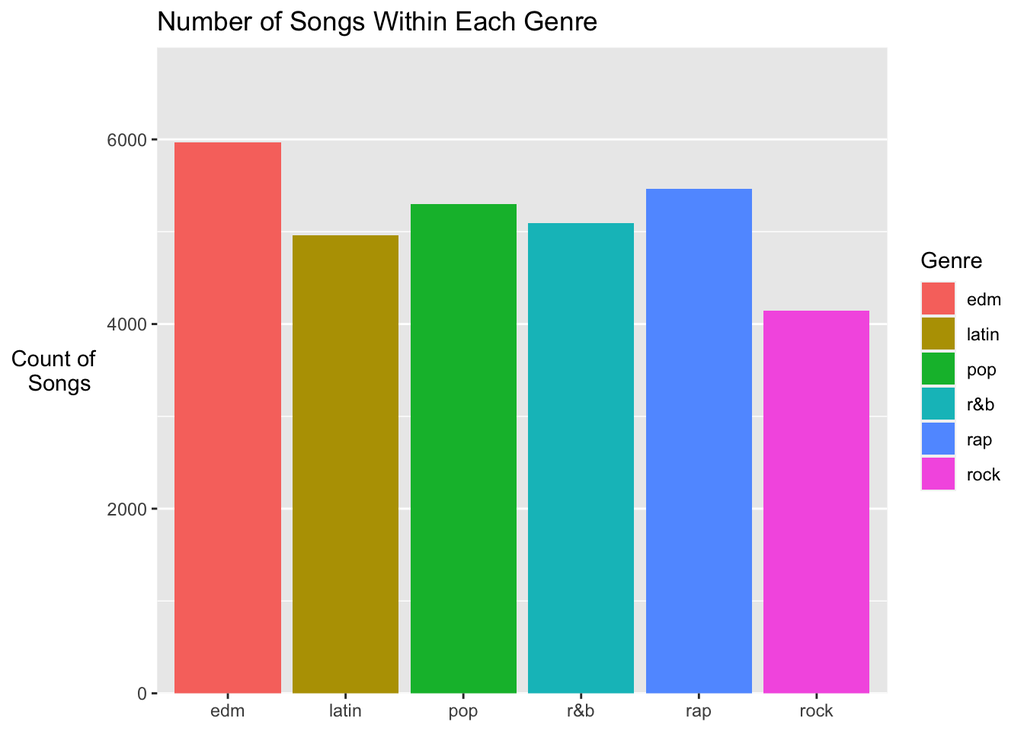

```r
songs %>% ggplot(aes(x = playlist_genre, fill = playlist_genre)) +
  geom_bar() +
  ggtitle("Number of Songs Within Each Genre") +
  scale_fill_discrete(name = "Genre") +
  scale_x_discrete(name = NULL) +
  scale_y_continuous(expand = c(0, 0), name = "Count of \n Songs") +
  theme(axis.title.y = element_text(angle = 0, vjust = .5)) +
  theme(panel.grid.major.x = element_blank()) +
  coord_cartesian(ylim = c(0, 7000))
```

As we can see, the makeup of songs in our dataset is pretty even, with EDM at the highest and rock at the lowest.

How do the genres rank in terms of popularity?

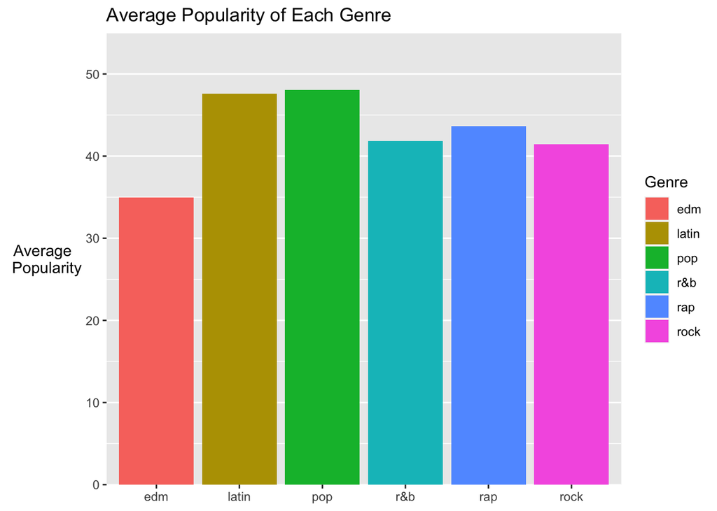

```r
popularity_means <- songs %>%
  group_by(playlist_genre) %>%
  dplyr::summarize(mean_popularity = mean(track_popularity))

popularity_means %>%
  ggplot(aes(x = playlist_genre,
             y = mean_popularity,
             fill = playlist_genre)) +
  geom_bar(stat = "identity") +
  ggtitle("Average Popularity of Each Genre") +
  scale_fill_discrete(name = "Genre") +
  scale_x_discrete(name = NULL) +
  scale_y_continuous(expand = c(0,0), name = "Average \n Popularity") +
  theme(axis.title.y = element_text(angle = 0, vjust = .5)) +
  theme(panel.grid.major.x = element_blank()) +
  coord_cartesian(ylim = c(0, 55))
```

Who are the most and least popular artists with at least five tracks in the dataset?

**Most popular:**

```r
# most popular
songs %>%
  group_by(track_artist) %>%
  filter(n() >= 5) %>%
  dplyr::summarize(mean_popularity = mean(track_popularity)) %>%
  arrange(desc(mean_popularity)) %>%
  slice_head(n = 10)
```

```
## # A tibble: 10 x 2
##    track_artist  mean_popularity
##    <chr>                   <dbl>
##  1 Trevor Daniel            97
##  2 Y2K                      91
##  3 Don Toliver              90.7
##  4 Roddy Ricch              88.2
##  5 DaBaby                   87.9
##  6 Kina                     85.4
##  7 JACKBOYS                 85.2
##  8 YNW Melly                84.6
##  9 Tainy                    84
## 10 Lewis Capaldi            83.7
```

**Least popular:**

```r
# least popular
songs %>%
  group_by(track_artist) %>%
  filter(n() >= 5) %>%
  dplyr::summarize(mean_popularity = mean(track_popularity)) %>%
  arrange(mean_popularity) %>%
  slice_head(n = 10)
```

```
## # A tibble: 10 x 2
##    track_artist         mean_popularity
##    <chr>                          <dbl>
##  1 Ballin Entertainment             0
##  2 CASIOPEA                         0
##  3 Hanybal                          0
##  4 Jamie Jones                      0
##  5 LemKuuja                         0
##  6 Lisa McClendon                   0
##  7 New World Sound                  0
##  8 T-SQUARE                         0
##  9 Green Tea                        0.5
## 10 Adventure Club                   0.6
```

Let’s look at the makeup of our dataset in terms of time. What dates are covered?

**Oldest track:**

```r
min(songs$track_album_release_date)
```

```
## [1] "1957-01-01"
```

**Newest track:**

```r
max(songs$track_album_release_date)
```

```
## [1] "2020-01-29"
```

Next we look at the popularity of songs by year, using color to denote genre.

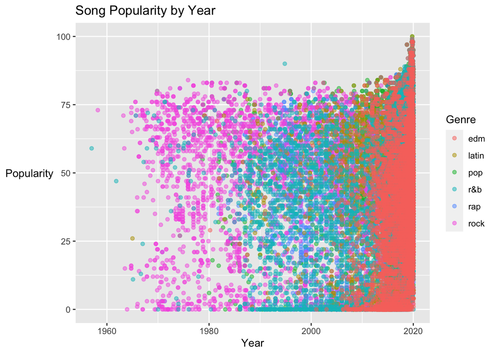

```r
songs %>% ggplot(aes(x = track_album_release_date, y = track_popularity, color = playlist_genre)) +
  geom_point(alpha = .5) +
  ggtitle("Song Popularity by Year") +
  scale_y_continuous(name = "Popularity") +
  labs(color = "Genre", x = "Year") +
  theme(axis.title.y = element_text(angle = 0, vjust = .5))
```

This plot is interesting, as it shows the timeline of when specific genres start to become dominant.

We will now compare genre characteristics in boxplots.

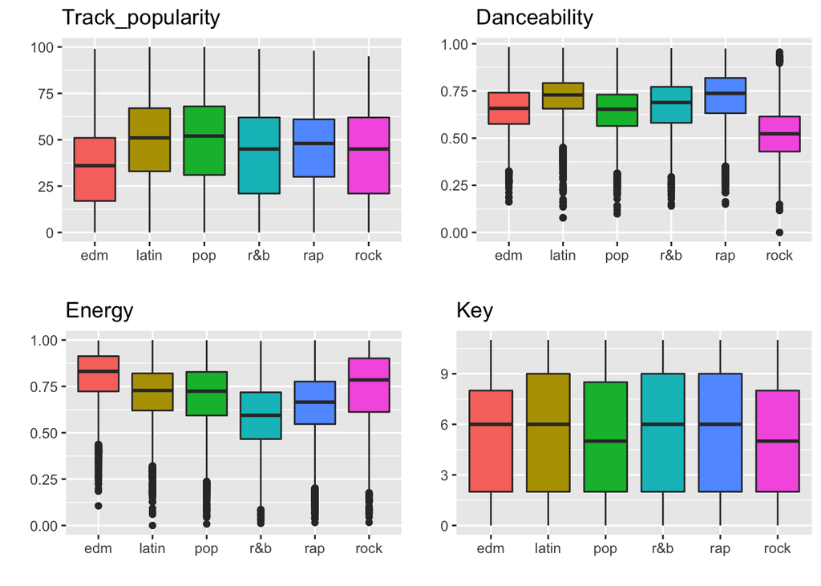

```r
myplots <-
  map(names(songs %>% select(where(is.numeric)) %>% select(-mode)),
      function(colName) {
        songs %>%
          ggplot(aes(x = playlist_genre,
                     y = !! sym(colName),
                     fill = playlist_genre)) +
          geom_boxplot() +
          theme(legend.position = "NONE") +
          labs(title = capitalize(colName), x = "", y = "")
    })
gridExtra::grid.arrange(grobs = myplots[c(1:4)])
```

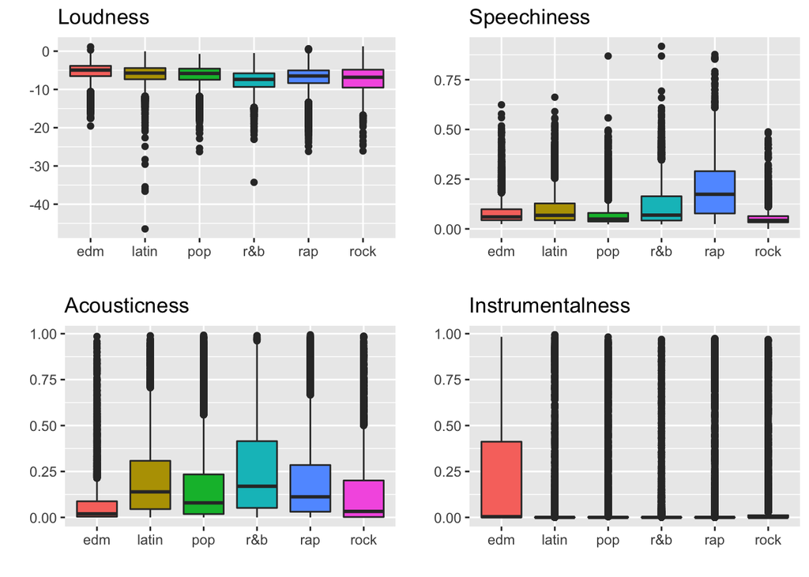

```r
gridExtra::grid.arrange(grobs = myplots[c(5:8)])
```

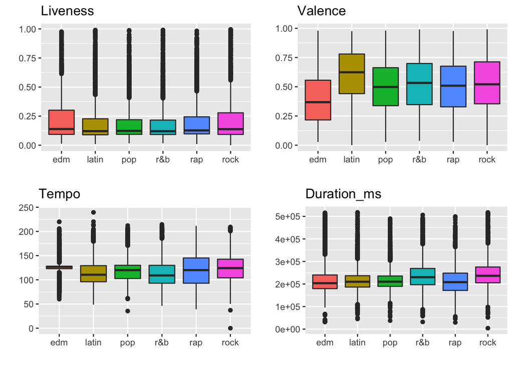

```r
gridExtra::grid.arrange(grobs = myplots[c(9:12)])
```

We now compare the variables in pairs to determine if any influence the other, and whether they are significant to the overall model. New variable creation will not be necessary.

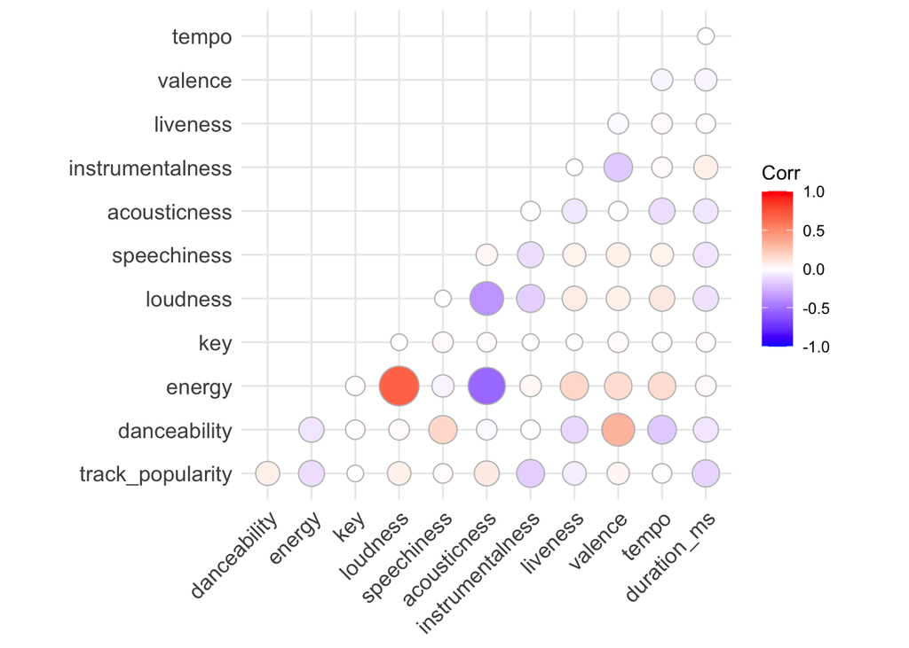

```r
corr_songs <-cor(songs %>% select(where(is.numeric)) %>% select(-mode))
ggcorrplot(corr_songs, method = "circle", type ="lower")
```

We see few strong correlations. The most prevalent are `energy`, which correlates strongly with `loudness`, and `loudness` and `energy` negatively correlated with `acousticness`, which makes intuitive sense.

Next, we will generate our explanatory multiple linear regression model by using forward selection to determine which variables will be used as covariates.

```r
# forward selection base model
add1(lm(track_popularity ~ 1, data = songs),
     track_popularity ~ danceability + energy + key + loudness
     + speechiness + acousticness + instrumentalness + liveness
     + valence + tempo,
     test = "F")

# instrumentalness has the highest significant F value, so add it first
add1(lm(track_popularity ~ instrumentalness, data = songs),
     track_popularity ~ danceability + energy + key + loudness
     + speechiness + acousticness + instrumentalness + liveness
     + valence + tempo,
     test = "F")

# add energy
add1(lm(track_popularity ~ instrumentalness + energy, data = songs),
     track_popularity ~ danceability + energy + key + loudness
     + speechiness + acousticness + instrumentalness + liveness
     + valence + tempo,
     test = "F")

# add loudness
add1(lm(track_popularity ~ instrumentalness + energy + loudness,
        data = songs),
     track_popularity ~ danceability + energy + key + loudness
     + speechiness + acousticness + instrumentalness + liveness
     + valence + tempo,
     test = "F")

# add valence
add1(lm(track_popularity ~ instrumentalness + energy + loudness + valence,
        data = songs),
     track_popularity ~ danceability + energy + key + loudness
     + speechiness + acousticness + instrumentalness + liveness
     + valence + tempo,
     test = "F")

# add liveness
add1(lm(track_popularity ~ instrumentalness + energy + loudness + valence
        + liveness,
        data = songs),
     track_popularity ~ danceability + energy + key + loudness
     + speechiness + acousticness + instrumentalness + liveness
     + valence + tempo,
     test = "F")

# add acousticness
add1(lm(track_popularity ~ instrumentalness + energy + loudness + valence
        + liveness + acousticness,
        data = songs),
     track_popularity ~ danceability + energy + key + loudness
     + speechiness + acousticness + instrumentalness + liveness
     + valence + tempo,
     test = "F")

# add danceability
add1(lm(track_popularity ~ instrumentalness + energy + loudness + valence
        + liveness + acousticness + danceability,
        data = songs),
     track_popularity ~ danceability + energy + key + loudness
     + speechiness + acousticness + instrumentalness + liveness
     + valence + tempo,
     test = "F")

# add tempo
add1(lm(track_popularity ~ instrumentalness + energy + loudness + valence
        + liveness + acousticness + danceability + tempo,
        data = songs),
     track_popularity ~ danceability + energy + key + loudness
     + speechiness + acousticness + instrumentalness + liveness
     + valence + tempo,
     test = "F")

# add speechiness
add1(lm(track_popularity ~ instrumentalness + energy + loudness + valence
        + liveness + acousticness + danceability + tempo + speechiness,
        data = songs),
     track_popularity ~ danceability + energy + key + loudness
     + speechiness + acousticness + instrumentalness + liveness
     + valence + tempo,
     test = "F")

# key is not found to be significant
```

[output not shown]

Based on our forward selection process, our model will use `instrumentalness`, `energy`, `loudness`, `valence`, `liveness`, `acousticness`, `danceability`, `tempo`, and `speechiness` as covariates for the response variable `track_popularity`. `key` was not found to be significant, so it will not be included in the model.

```r
model1 <- lm(track_popularity ~ instrumentalness + energy + loudness + valence
             + liveness + acousticness + danceability + tempo + speechiness,
             data = songs)
summary(model1)
```

```
##
## Call:
## lm(formula = track_popularity ~ instrumentalness + energy + loudness +
##     valence + liveness + acousticness + danceability + tempo +
##     speechiness, data = songs)
##
## Residuals:
##     Min      1Q  Median      3Q     Max
## -62.369 -17.262   3.129  18.874  78.202
##
## Coefficients:
##                    Estimate Std. Error t value Pr(>|t|)
## (Intercept)       69.600763   1.637877  42.494  < 2e-16 ***
## instrumentalness -12.463786   0.644196 -19.348  < 2e-16 ***
## energy           -31.884870   1.240935 -25.694  < 2e-16 ***
## loudness           1.784146   0.066932  26.656  < 2e-16 ***
## valence            3.198616   0.662528   4.828 1.39e-06 ***
## liveness          -4.208941   0.913680  -4.607 4.11e-06 ***
## acousticness       4.687185   0.752145   6.232 4.67e-10 ***
## danceability       6.755458   1.083990   6.232 4.66e-10 ***
## tempo              0.023060   0.005275   4.372 1.24e-05 ***
## speechiness       -4.636935   1.388245  -3.340 0.000838 ***
## ---
## Signif. codes:  0 '***' 0.001 '**' 0.01 '*' 0.05 '.' 0.1 ' ' 1
##
## Residual standard error: 24.13 on 30932 degrees of freedom
## Multiple R-squared:  0.06471,    Adjusted R-squared:  0.06443
## F-statistic: 237.8 on 9 and 30932 DF,  p-value: < 2.2e-16
```

Our model only accounts for about 6% of the variation in `track_popularity`. Let’s take a look at the QQ plot and histogram of our residuals to see if any improvements can be made.

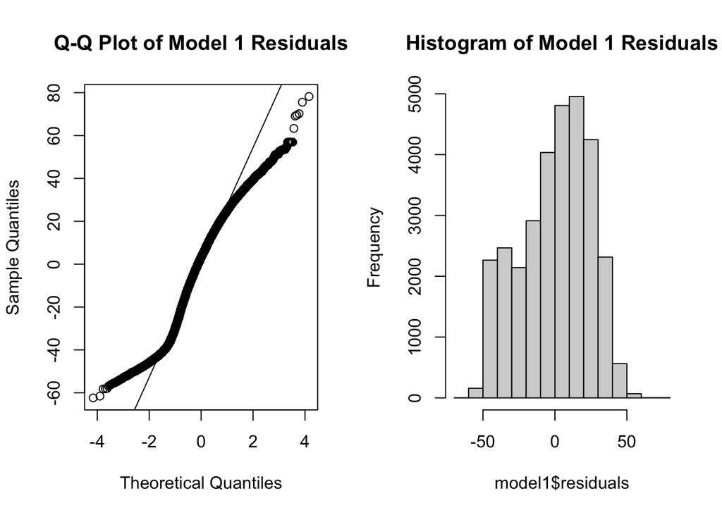

```r
par(mfrow = c(1,2))
qqnorm(model1$residuals, main = "Q-Q Plot of Model 1 Residuals")
qqline(model1$residuals)
hist(model1$residuals, main = "Histogram of Model 1 Residuals")
```

```r
par(mfrow = c(1,1))
```

The QQ plot of the residuals shows a pattern that indicates non-normality in our residuals, and the histogram reveals light tails. These results suggest that transforming our response variable might be in order, so let’s try that. We’ll create five alternative models using the following transformations on `track_popularity`:

- square root transformation
- log transformation
- reciprocal square root transformation
- reciprocal transformation
- arcsin transformation

```r
# square root transformation
songs$sqrt_track_popularity <- sqrt(songs$track_popularity)
model2 <- lm(sqrt_track_popularity ~ instrumentalness + energy + loudness +
               valence + liveness + acousticness + danceability + tempo +
               speechiness,
             data = songs)

# log transformation
songs$log_track_popularity <- log(songs$track_popularity)
model3 <- lm(log_track_popularity ~ instrumentalness + energy + loudness +
               valence + liveness + acousticness + danceability + tempo +
               speechiness,
             data = songs[songs$log_track_popularity > -Inf,])

# reciprocal square root transformation
songs$recip_sqrt_track_popularity <- songs$track_popularity ^ (-.5)
model4 <- lm(recip_sqrt_track_popularity ~ instrumentalness + energy + loudness +
               valence + liveness + acousticness + danceability + tempo +
               speechiness,
             data = songs[songs$log_track_popularity > -Inf,])

# reciprocal transformation
songs$recip_track_popularity <- songs$track_popularity ^ (-1)
model5 <- lm(recip_track_popularity ~ instrumentalness + energy + loudness +
               valence + liveness + acousticness + danceability + tempo +
               speechiness,
             data = songs[songs$recip_sqrt_track_popularity < Inf,])

# arcsin transformation
songs$asin_track_popularity <- asin(songs$sqrt_track_popularity)
model6 <- lm(asin_track_popularity ~ instrumentalness + energy + loudness +
               valence + liveness + acousticness + danceability + tempo +
               speechiness,
             data = songs[!(is.nan(songs$asin_track_popularity)),])
```

Unfortunately, none of our transformations had a beneficial effect on our residuals, as can be seen in the QQ plots of our alternate models.

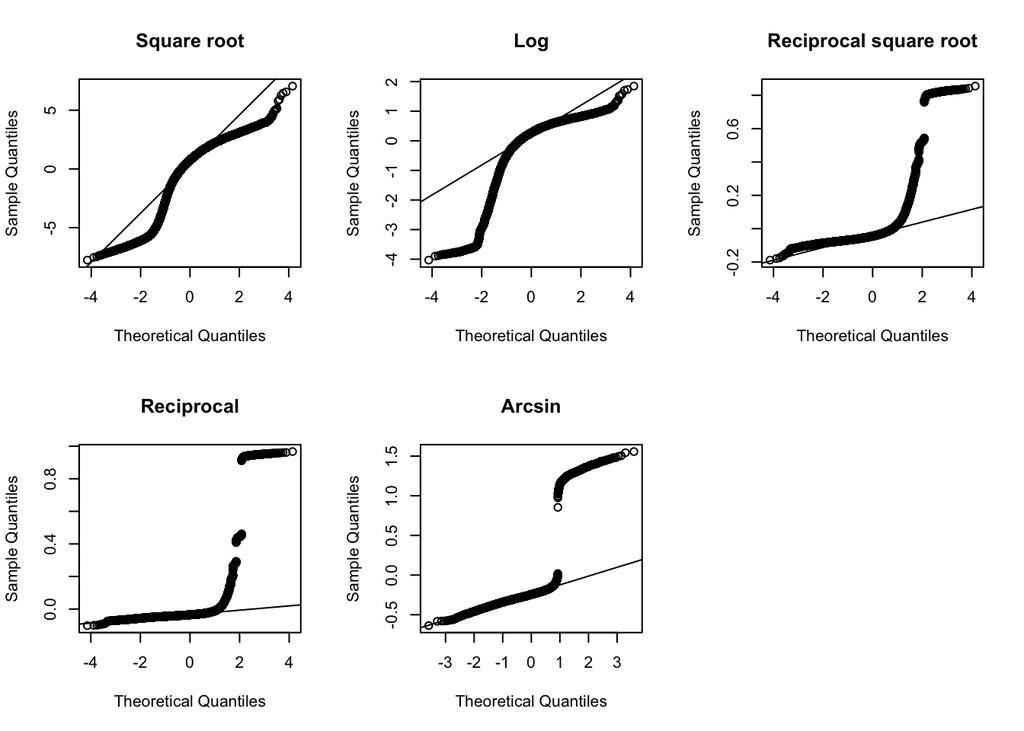

```r
par(mfrow = c(2, 3))

qqnorm(model2$residuals, main = "Square root")
qqline(model2$residuals)

qqnorm(model3$residuals, main = "Log")
qqline(model3$residuals)

qqnorm(model4$residuals, main = "Reciprocal square root")
qqline(model4$residuals)

qqnorm(model5$residuals, main = "Reciprocal")
qqline(model5$residuals)

qqnorm(model6$residuals, main = "Arcsin")
qqline(model6$residuals)

par(mfrow = c(1,1))
```

We can also tell by looking at our models’ adjusted R-squared values that our original model performs better than any of our alternative models.

```r
(df <- data.frame(Model = c(1:6),
                 Transformation = c("None",
                                    "Square root",
                                    "Log",
                                    "Reciprocal square root",
                                    "Reciprocal",
                                    "Arcsin"),
                 AdjRsqr = c(summary(model1)$adj.r.squared,
                             summary(model2)$adj.r.squared,
                             summary(model3)$adj.r.squared,
                             summary(model4)$adj.r.squared,
                             summary(model5)$adj.r.squared,
                             summary(model6)$adj.r.squared)))
```

```
##   Model         Transformation     AdjRsqr
## 1     1                   None 0.064434292
## 2     2            Square root 0.050388224
## 3     3                    Log 0.024922753
## 4     4 Reciprocal square root 0.009597271
## 5     5             Reciprocal 0.003216709
## 6     6                 Arcsin 0.020659481
```